# Mt. Everest

Mountain Everest Deaths and Ascents between 1922-2020.

| [Time in Nepal](http://24timezones.com/current_local/nepal_time.php) |
| --- |

Nepal[^1] is tomorrow~

# Map

[figure not shown]

# Dataset

I got two datasets, peak ascents and deaths reports for Everest from [The Himalayan Database](https://www.himalayandatabase.com/index.html) and combined them into one dataset. Most other online databases only provide one or two recent year data for free, and I didn’t find more available data, so this dataset has limited variables for analysis. Probably could add some weather data like daily wind speed and average temperature as predictors. 👉[National Geographic](https://www.nationalgeographic.org/projects/perpetual-planet/everest/weather-data/)

something is wrong here, NA is more than 215, and the totals are not equal?

```r
NA_cnt <- table(is.na(total))
NA_pct <- prop.table(NA_cnt)
cbind(NA_cnt, NA_pct)
```

```
      NA_cnt      NA_pct
FALSE 135076 0.998410833
TRUE     215 0.001589167
```

```r
total <- VIM::kNN(total,
                  variable = c("Age", "Oxy"),
                  k = 10)
total <- total[, -c(15:16)]
table(is.na(total))
```

```
 FALSE
145698
```

```r
counts <- table(total$Dth)
proportions <- prop.table(counts)
cbind(counts, proportions)
```

```
  counts proportions
0  10101  0.97059671
1    306  0.02940329
```

# Plots

Age Male climbers’ age range is wider than females due to some outliers. We can see the oldest climbers are over 80. 50% of death in females are between the age of 30-50 while males are between 30-45. Both genders’ interquartile ranges are similar among success ascents groups.

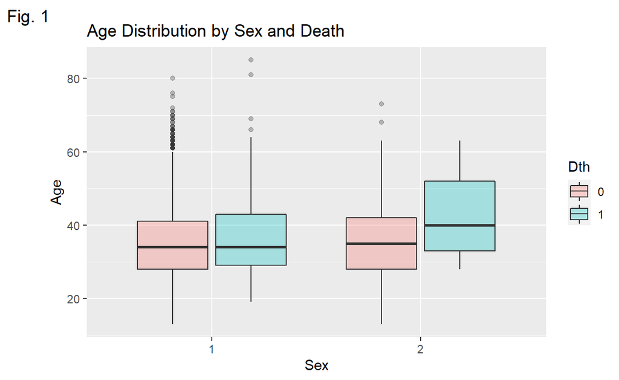

```r
ggplot(data = total,
       mapping = aes(x = Sex,
                     y = Age,
                     fill = Dth), na.rm = TRUE) +
  labs(x = "Sex",
       y = "Age",
       title = "Age Distribution by Sex and Death",
       tag = "Fig. 1") +
  geom_boxplot(alpha = .3)
```

Causes More people died the altitude below 7500m because of natural disasters compared to the altitude above 7500m. Death zone[^2] is defined as an altitude above 8000m, which can cause mountaineers to lose physical strength or even vital functions due to a low level of concentration of oxygen. I guess I could add some ratio variables for the death rates in different altitude zones? Like death zone and Khumbu Icefall?

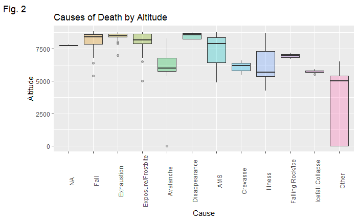

=(Had issues with some columns even though I had already removed the missing values and it did work when I ran the chunk individually. However, it did not work when I knit the whole post. 😩

[figure not shown]

```r
total %>%
  drop_na(Altitude) %>%
  ggplot(mapping = aes(x = Cause,
                       y = Altitude,
                       fill = Cause)) +
  labs(title = "Causes of Death by Altitude",
       tag = "Fig. 2") +
  geom_boxplot(alpha = .3) +
  theme(legend.position = "none",
        axis.text.x = element_text(angle = 90))
```

Oxy

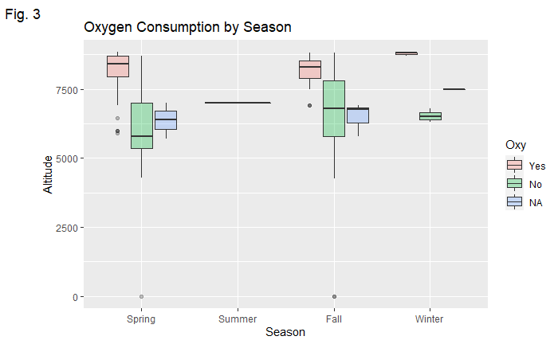

[figure not shown]

```r
order <- c(1, 2, 3, 4)
total %>%
  drop_na(Altitude) %>%
  ggplot(mapping = aes(x = factor(Season, level = order),
                       y = Altitude,
                       fill = Oxy)) +
  labs(title = "Oxygen Consumption by Season",
       x = "Season",
       tag = "Fig. 3") +
  geom_boxplot(alpha = .3) +
  scale_x_discrete(labels = c("1" = "Spring", "2" = "Summer", "3" = "Fall", "4" = "Winter")) +
  scale_fill_discrete(labels = c("Yes", "No", "NA"))
```

Oxy by Age Most climbers are between 25-45 years old

[figure not shown]

[figure not shown]

```r
total %>%
  drop_na(Age) %>%
  ggplot(mapping = aes(x = Age,
                     fill = Oxy)) +
  geom_histogram(position = "stack",
                 alpha = .6,
                 stat="count") +
  labs(title = "Histogram: Credit Limit vs Attrition",
       tag = "Fig. 4")
```

Oxy by Altitude Higher consumption of oxygen above 7500m altitude.

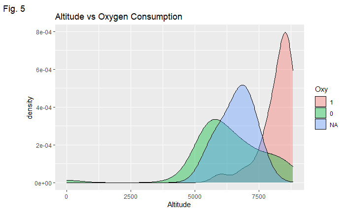

[figure not shown]

```r
total %>%
  drop_na(Altitude) %>%
  ggplot(mapping = aes(x = Altitude,
                       group = Oxy,
                       fill = Oxy)) +
  geom_density(adjust = 1.5, alpha = .4) +
  labs(title = "Altitude vs Oxygen Consumption",
       tag = "Fig. 5")
```

Season Most expeditions happened in spring and some in the fall

[figure not shown]

```r
order <- c(1, 2, 3, 4)
total %>%
  drop_na(Altitude) %>%
  ggplot(mapping = aes(x = Altitude,
                       fill = factor(Season, level = order))) +
  geom_histogram(position = "stack",
                 alpha = .5) +
  labs(title = "Altitude vs Season",
       tag = "Fig. 6") +
  scale_fill_discrete(name = "Season", labels = c("Spring", "Summer", "Fall", "Winter"))
```

[output not shown]

# Result

```r
comparison <- matrix(c(0.9199, 0.2818, 0.6264, 0.9287,
                       0.9327, 0.3152, 0.6044, 0.9426,
                       0.9503, 0.3963, 0.6154, 0.9604),
                     ncol = 4, byrow = TRUE)
colnames(comparison) <- c("Accuracy", "Kappa", "Recall", "Sepecificity")
rownames(comparison) <- c("i.SMOTE", "ii.UP", "iii.DOWN")
comparison <- as.data.frame.matrix(comparison)
kable(comparison) %>%
  row_spec(3, color = "white", background = "#bdaeea")
```

|  | Accuracy | Kappa | Recall | Sepecificity |
| --- | --- | --- | --- | --- |
| i.SMOTE | 0.9199 | 0.2818 | 0.6264 | 0.9287 |
| ii.UP | 0.9327 | 0.3152 | 0.6044 | 0.9426 |
| iii.DOWN | 0.9503 | 0.3963 | 0.6154 | 0.9604 |

# Code

## i. My logistic regression does not work=(

```r
index <- createDataPartition(total1$Dth, p = .7, list = FALSE, times = 1)

train <- total1[index,]
test <- total1[-index,]

glm <- train(
  form = Dth ~ Age + factor(Oxy),
  data = train,
  trContrl =trainControl(method = "cv", number = 10),
  method = "glm",
  family = "binomial",
  na.action = na.omit
)
```

```
Something is wrong; all the Accuracy metric values are missing:
    Accuracy       Kappa
 Min.   : NA   Min.   : NA
 1st Qu.: NA   1st Qu.: NA
 Median : NA   Median : NA
 Mean   :NaN   Mean   :NaN
 3rd Qu.: NA   3rd Qu.: NA
 Max.   : NA   Max.   : NA
 NA's   :1     NA's   :1
```

```
Error: Stopping
```

## ii. knn with SMOTE

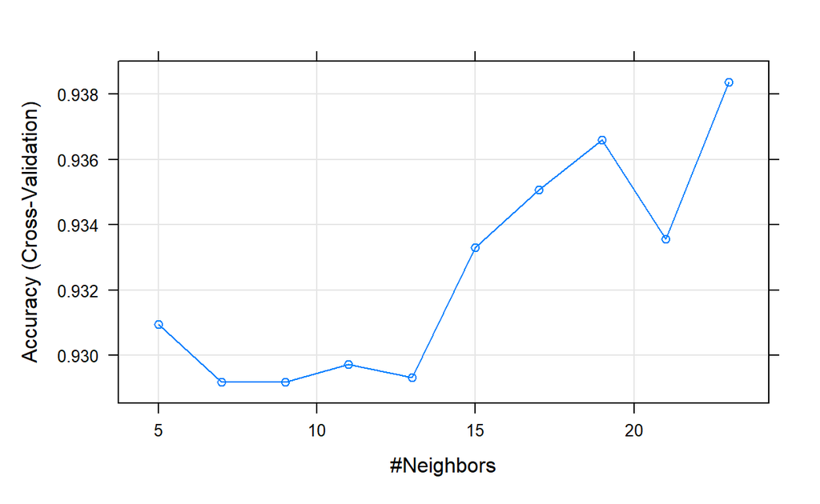

```r
knn1 <- train(
  Dth ~ factor(Season) + factor(Sex) + Age + factor(Oxy),
  data = train,
  method = "knn",
  trControl = trainControl(method = "cv", number = 10,
                           sampling = "smote"),
  preProcess = c("center", "scale"),
  tuneLength = 10,
  na.action = na.omit
)

plot(knn1)
```

```r
knn1$bestTune
```

```
    k
10 23
```

```r
pred1 <- predict(knn1, test)
confusionMatrix(pred1, test$Dth,
                positive = "1")
```

```
Confusion Matrix and Statistics

          Reference
Prediction    0    1
         0 2814   34
         1  216   57

               Accuracy : 0.9199
                 95% CI : (0.9098, 0.9292)
    No Information Rate : 0.9708
    P-Value [Acc > NIR] : 1

                  Kappa : 0.2818

 Mcnemar's Test P-Value : <2e-16

            Sensitivity : 0.62637
            Specificity : 0.92871
         Pos Pred Value : 0.20879
         Neg Pred Value : 0.98806
             Prevalence : 0.02916
         Detection Rate : 0.01826
   Detection Prevalence : 0.08747
      Balanced Accuracy : 0.77754

       'Positive' Class : 1
```

## iii. knn with Up

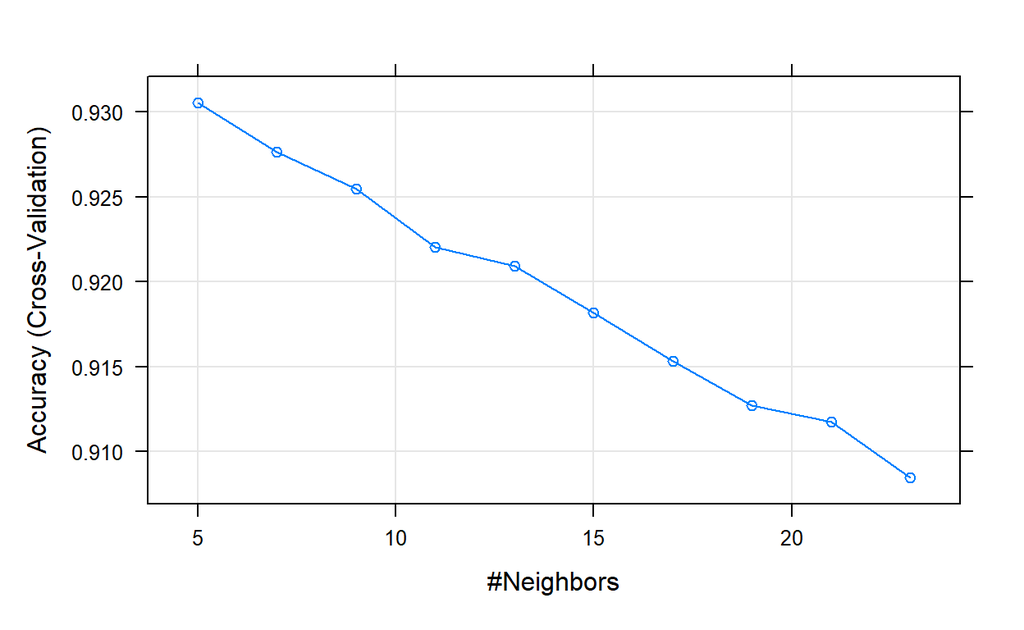

```r
knn3 <- train(
  Dth ~ factor(Season) + factor(Sex) + Age + factor(Oxy),
  data = train,
  method = "knn",
  trControl = trainControl(method = "cv", number = 10,
                           sampling = "up"),
  preProcess = c("center", "scale"),
  tuneLength = 10
)

plot(knn3)
```

```r
knn3$bestTune
```

```
  k
1 5
```

```r
pred3 <- predict(knn3, test)
confusionMatrix(pred3, test$Dth,
                positive = "1")
```

```
Confusion Matrix and Statistics

          Reference
Prediction    0    1
         0 2856   36
         1  174   55

               Accuracy : 0.9327
                 95% CI : (0.9234, 0.9413)
    No Information Rate : 0.9708
    P-Value [Acc > NIR] : 1

                  Kappa : 0.3152

 Mcnemar's Test P-Value : <2e-16

            Sensitivity : 0.60440
            Specificity : 0.94257
         Pos Pred Value : 0.24017
         Neg Pred Value : 0.98755
             Prevalence : 0.02916
         Detection Rate : 0.01762
   Detection Prevalence : 0.07337
      Balanced Accuracy : 0.77348

       'Positive' Class : 1
```

## iv. knn with Down

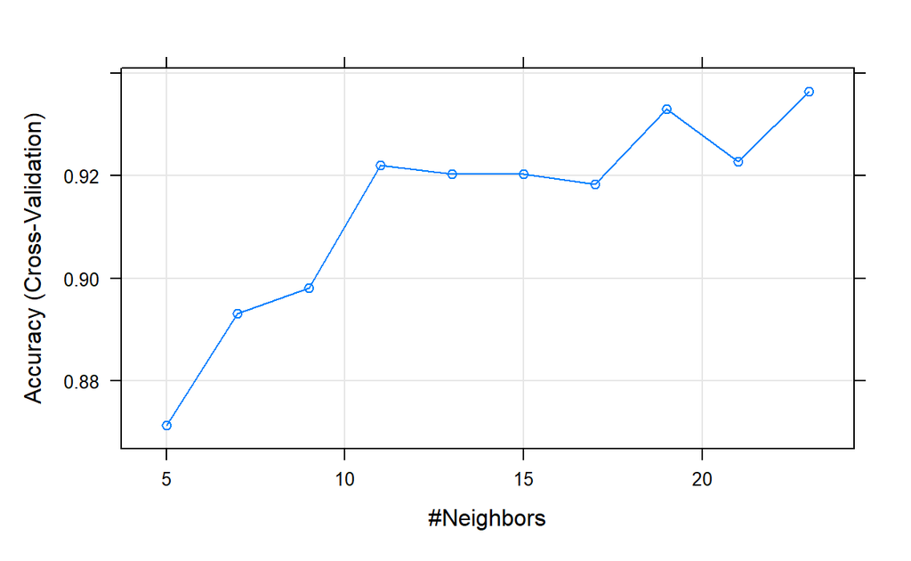

```r
knn4 <- train(
  Dth ~ factor(Season) + factor(Sex) + Age + factor(Oxy),
  data = train,
  method = "knn",
  trControl = trainControl(method = "cv", number = 10,
                           sampling = "down"),
  preProcess = c("center", "scale"),
  tuneLength = 10,
  na.action = na.omit
)

plot(knn4)
```

```r
knn4$bestTune
```

```
    k
10 23
```

```r
pred4 <- predict(knn4, test)
confusionMatrix(pred4, test$Dth,
                positive = "1")
```

```
Confusion Matrix and Statistics

          Reference
Prediction    0    1
         0 2910   35
         1  120   56

               Accuracy : 0.9503
                 95% CI : (0.9421, 0.9577)
    No Information Rate : 0.9708
    P-Value [Acc > NIR] : 1

                  Kappa : 0.3963

 Mcnemar's Test P-Value : 1.509e-11

            Sensitivity : 0.61538
            Specificity : 0.96040
         Pos Pred Value : 0.31818
         Neg Pred Value : 0.98812
             Prevalence : 0.02916
         Detection Rate : 0.01794
   Detection Prevalence : 0.05639
      Balanced Accuracy : 0.78789

       'Positive' Class : 1
```

R.I.P all the bodies and Hillary Step

[^1]: https://24timezones.com/Nepal/time
[^2]: https://en.wikipedia.org/wiki/Death_zone